# Intro-stats_ENVS401-501

W. Austin Rutherford

10/26/2021

# Learning Objectives

1. Examine data for testing and validating assumptions
2. Extract relevant portions of datasets for testing
3. Run standard parametric statistical tests in R, including Student’s t, analysis of variance (ANOVA), and simple linear regression.

## Data exploration

Learn about your data before jumping into any testing

```r
knitr::opts_chunk$set(echo = TRUE)
```

```r
# Intro to Stats in R for ENVS 401/501
# Austin Rutherford
# Date: 2021-10-25
# Email: arutherford@email.arizona.edu

# load (or install) needed packages
#install.packages("palmerpenguins")

library(palmerpenguins)
library(tidyverse)
# examine your data
head(penguins)
```

| species | island | bill_length_mm | bill_depth_mm | flipper_length_mm | body_mass_g | sex | year |
| --- | --- | --- | --- | --- | --- | --- | --- |
| Adelie | Torgersen | 39.1 | 18.7 | 181 | 3750 | male | 2007 |
| Adelie | Torgersen | 39.5 | 17.4 | 186 | 3800 | female | 2007 |
| Adelie | Torgersen | 40.3 | 18.0 | 195 | 3250 | female | 2007 |
| Adelie | Torgersen | NA | NA | NA | NA | NA | 2007 |
| Adelie | Torgersen | 36.7 | 19.3 | 193 | 3450 | female | 2007 |
| Adelie | Torgersen | 39.3 | 20.6 | 190 | 3650 | male | 2007 |

```r
glimpse(penguins)
```

```
## Rows: 344
## Columns: 8
## $ species           <fct> Adelie, Adelie, Adelie, Adelie, Adelie, Adelie, A...
## $ island            <fct> Torgersen, Torgersen, Torgersen, Torgersen, Torge...
## $ bill_length_mm    <dbl> 39.1, 39.5, 40.3, NA, 36.7, 39.3, 38.9, 39.2, 34....
## $ bill_depth_mm     <dbl> 18.7, 17.4, 18.0, NA, 19.3, 20.6, 17.8, 19.6, 18....
## $ flipper_length_mm <int> 181, 186, 195, NA, 193, 190, 181, 195, 193, 190, ...
## $ body_mass_g       <int> 3750, 3800, 3250, NA, 3450, 3650, 3625, 4675, 347...
## $ sex               <fct> male, female, female, NA, female, male, female, m...
## $ year              <int> 2007, 2007, 2007, 2007, 2007, 2007, 2007, 2007, 2...
```

```r
summary(penguins)
```

```
##       species          island    bill_length_mm  bill_depth_mm
##  Adelie   :152   Biscoe   :168   Min.   :32.10   Min.   :13.10
##  Chinstrap: 68   Dream    :124   1st Qu.:39.23   1st Qu.:15.60
##  Gentoo   :124   Torgersen: 52   Median :44.45   Median :17.30
##                                  Mean   :43.92   Mean   :17.15
##                                  3rd Qu.:48.50   3rd Qu.:18.70
##                                  Max.   :59.60   Max.   :21.50
##                                  NA's   :2       NA's   :2
##  flipper_length_mm  body_mass_g       sex           year
##  Min.   :172.0     Min.   :2700   female:165   Min.   :2007
##  1st Qu.:190.0     1st Qu.:3550   male  :168   1st Qu.:2007
##  Median :197.0     Median :4050   NA's  : 11   Median :2008
##  Mean   :200.9     Mean   :4202                Mean   :2008
##  3rd Qu.:213.0     3rd Qu.:4750                3rd Qu.:2009
##  Max.   :231.0     Max.   :6300                Max.   :2009
##  NA's   :2         NA's   :2
```

## t-test

- statistic method used to determine if there is a significant difference between the means of two groups based on a sample of data.
- The test relies on a set of assumptions for it to be interpreted properly and with validity.
  - first assumption
    - continuous or ordinal scale data
  - second assumption
    - simple random sample, that the data is collected from a representative, randomly selected portion of the total population
  - third assumption
    - data, when plotted, results in a normal distribution, bell-shaped distribution curve.
      - normal distribution allows you to specify a level of probability (alpha level (5%), level of significance, p)
  - fourth assumption
  - reasonably large sample size
  - Fifth assumption
    - homogeneity of variance. Homogeneous, or equal, variance exists when the standard deviations of samples are approximately equal
- Among these assumptions, the data must be randomly sampled from the population of interest and the data variables must follow a normal distribution.

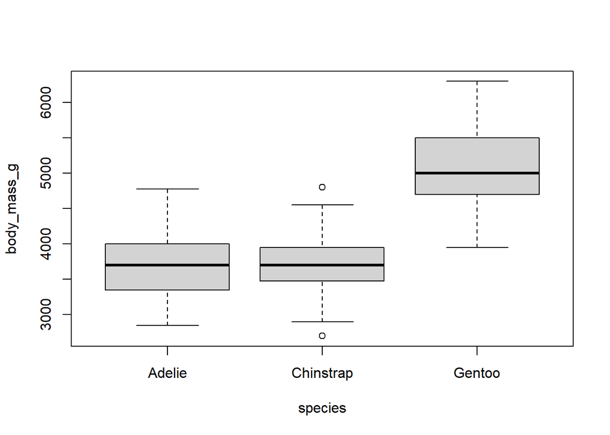

```r
# A question I have, is there a statistical difference in mean body mass between the Adelie and Gentoo penguin species?

# base R
boxplot(formula = body_mass_g ~ species, data = penguins)
```

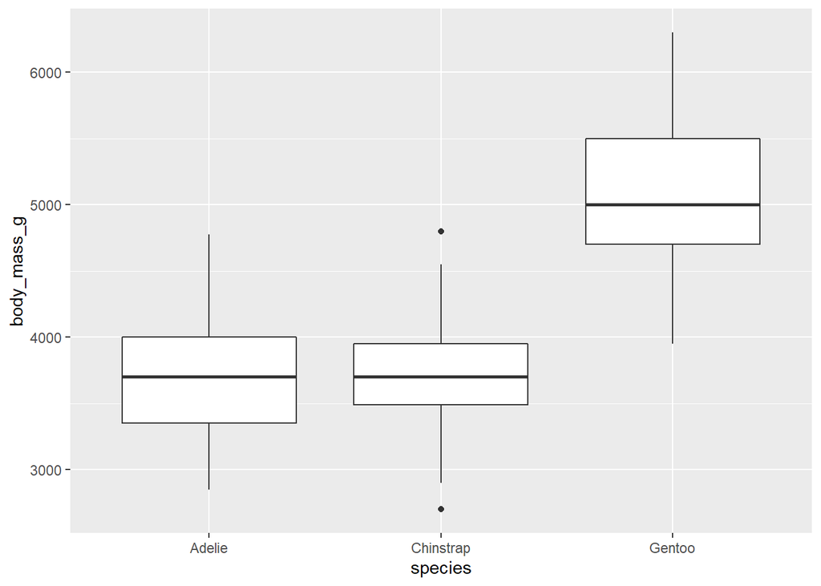

```r
# ggplot
penguins %>%
  ggplot(mapping = aes(x = species, y = body_mass_g)) +
  geom_boxplot()
```

```r
# t-test means between two groups, our groups = Adelie and Gentoo
adelie <- penguins %>%
  filter(species == "Adelie")

glimpse(adelie)
```

```
## Rows: 152
## Columns: 8
## $ species           <fct> Adelie, Adelie, Adelie, Adelie, Adelie, Adelie, A...
## $ island            <fct> Torgersen, Torgersen, Torgersen, Torgersen, Torge...
## $ bill_length_mm    <dbl> 39.1, 39.5, 40.3, NA, 36.7, 39.3, 38.9, 39.2, 34....
## $ bill_depth_mm     <dbl> 18.7, 17.4, 18.0, NA, 19.3, 20.6, 17.8, 19.6, 18....
## $ flipper_length_mm <int> 181, 186, 195, NA, 193, 190, 181, 195, 193, 190, ...
## $ body_mass_g       <int> 3750, 3800, 3250, NA, 3450, 3650, 3625, 4675, 347...
## $ sex               <fct> male, female, female, NA, female, male, female, m...
## $ year              <int> 2007, 2007, 2007, 2007, 2007, 2007, 2007, 2007, 2...
```

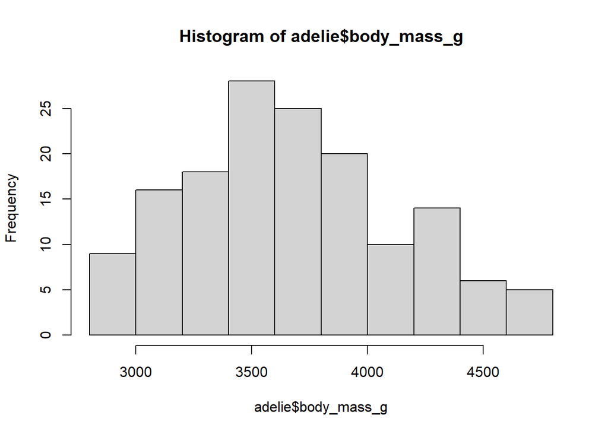

```r
# visualize normality assumption
hist(adelie$body_mass_g)
```

```r
# quick assessment of homogeneity of variance assumption, gotta check for NAs, sd don't like em
adelie %>% na.omit() %>%
  summarise(sd_mass = sd(body_mass_g))
```

| sd_mass |
| --- |
| 458.6201 |

```r
# extract only gentoo data
gentoo <- penguins %>%
  filter(species == "Gentoo")

glimpse(gentoo)
```

```
## Rows: 124
## Columns: 8
## $ species           <fct> Gentoo, Gentoo, Gentoo, Gentoo, Gentoo, Gentoo, G...
## $ island            <fct> Biscoe, Biscoe, Biscoe, Biscoe, Biscoe, Biscoe, B...
## $ bill_length_mm    <dbl> 46.1, 50.0, 48.7, 50.0, 47.6, 46.5, 45.4, 46.7, 4...
## $ bill_depth_mm     <dbl> 13.2, 16.3, 14.1, 15.2, 14.5, 13.5, 14.6, 15.3, 1...
## $ flipper_length_mm <int> 211, 230, 210, 218, 215, 210, 211, 219, 209, 215,...
## $ body_mass_g       <int> 4500, 5700, 4450, 5700, 5400, 4550, 4800, 5200, 4...
## $ sex               <fct> female, male, female, male, male, female, female,...
## $ year              <int> 2007, 2007, 2007, 2007, 2007, 2007, 2007, 2007, 2...
```

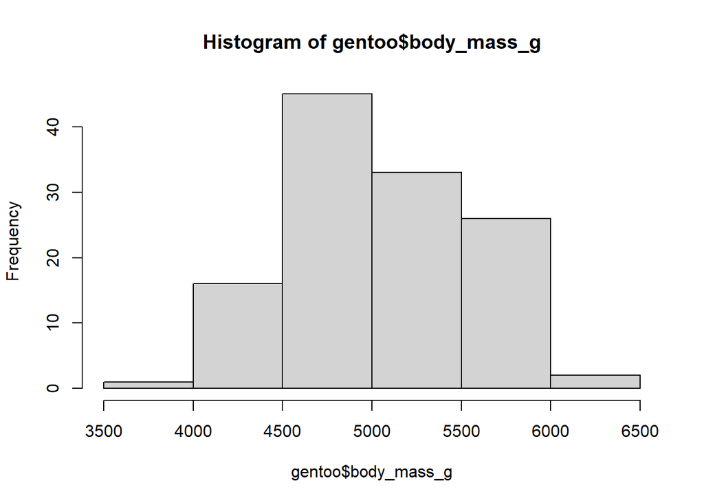

```r
# visualize normality assumption
hist(gentoo$body_mass_g)
```

```r
# quick look at homogeneity of variance
gentoo %>% na.omit() %>%
  summarise(sd_mass = sd(body_mass_g))
```

| sd_mass |
| --- |
| 501.4762 |

```r
# ready to do a t-test
penguin.mass.test <- t.test(x = adelie$body_mass_g, y = gentoo$body_mass_g)

# look at output of t-test
penguin.mass.test
```

```
##
##  Welch Two Sample t-test
##
## data:  adelie$body_mass_g and gentoo$body_mass_g
## t = -23.386, df = 249.64, p-value < 2.2e-16
## alternative hypothesis: true difference in means is not equal to 0
## 95 percent confidence interval:
##  -1491.183 -1259.525
## sample estimates:
## mean of x mean of y
##  3700.662  5076.016
```

```r
### Challenge 1
# is there a statistical difference in mean flipper length between the Adelie and Gentoo penguin species?
# test normality, look at the standard deviation, if cool, to a t-test

# hist(adelie$flipper_length_mm)
# hist(gentoo$flipper_length_mm)
#
# adelie %>% na.omit() %>%
#   summarise(sd_mass = sd(flipper_length_mm))
#
# gentoo %>% na.omit() %>%
#   summarise(sd_mass = sd(flipper_length_mm))
#
# penguin.flipper.test <- t.test(x = adelie$flipper_length_mm, y = gentoo$flipper_length_mm)
# penguin.flipper.test

# save outputs to a text file, really helpful for reporting later
sink(file = "Output/penguin-mass-t-test.txt")
penguin.mass.test
```

```
##
##  Welch Two Sample t-test
##
## data:  adelie$body_mass_g and gentoo$body_mass_g
## t = -23.386, df = 249.64, p-value < 2.2e-16
## alternative hypothesis: true difference in means is not equal to 0
## 95 percent confidence interval:
##  -1491.183 -1259.525
## sample estimates:
## mean of x mean of y
##  3700.662  5076.016
```

```r
sink()
```

## ANOVA (Analysis of Variance)

- one-way ANOVA or one-factor ANOVA is an extension of t-test
- comparing means where there are more than two groups.
- data is organized into several groups base on one single grouping variable (also called factor variable in R)
- Hypothesis testing
  - Null hypothesis: the means of the different groups are the same
  - Alternative hypothesis: At least one sample mean is not equal to the others.
- Assumptions, like t-test
  - The observations are obtained independently and randomly from the population defined by the factor levels
  - Each factor level is normally distributed
  - Homogeneity of variance
- If only two levels/factors, can just use t-test
- Tests across all factors, help with knowing which factors/groups are significantly different from each other (post-hoc)

```r
# different data types in R, factor = groups or categorical data
glimpse(penguins)
```

```
## Rows: 344
## Columns: 8
## $ species           <fct> Adelie, Adelie, Adelie, Adelie, Adelie, Adelie, A...
## $ island            <fct> Torgersen, Torgersen, Torgersen, Torgersen, Torge...
## $ bill_length_mm    <dbl> 39.1, 39.5, 40.3, NA, 36.7, 39.3, 38.9, 39.2, 34....
## $ bill_depth_mm     <dbl> 18.7, 17.4, 18.0, NA, 19.3, 20.6, 17.8, 19.6, 18....
## $ flipper_length_mm <int> 181, 186, 195, NA, 193, 190, 181, 195, 193, 190, ...
## $ body_mass_g       <int> 3750, 3800, 3250, NA, 3450, 3650, 3625, 4675, 347...
## $ sex               <fct> male, female, female, NA, female, male, female, m...
## $ year              <int> 2007, 2007, 2007, 2007, 2007, 2007, 2007, 2007, 2...
```

```r
# Check how many groups?
# Names of groups
levels(penguins$species)
```

```
## [1] "Adelie"    "Chinstrap" "Gentoo"
```

```r
# Count the groups
nlevels(penguins$species)
```

```
## [1] 3
```

```r
# Analysis of Variance
# Question: are there differences in body mass amoung three penguin species?
# Hypothesis: penguin species have different mean body masses, null H: no difference
penguin.mass.aov <- aov(formula = body_mass_g ~ species, data = penguins)

penguin.mass.aov
```

```
## Call:
##    aov(formula = body_mass_g ~ species, data = penguins)
##
## Terms:
##                   species Residuals
## Sum of Squares  146864214  72443483
## Deg. of Freedom         2       339
##
## Residual standard error: 462.2744
## Estimated effects may be unbalanced
## 2 observations deleted due to missingness
```

```r
summary(object = penguin.mass.aov)
```

```
##              Df    Sum Sq  Mean Sq F value Pr(>F)
## species       2 146864214 73432107   343.6 <2e-16 ***
## Residuals   339  72443483   213698
## ---
## Signif. codes:  0 '***' 0.001 '**' 0.01 '*' 0.05 '.' 0.1 ' ' 1
## 2 observations deleted due to missingness
```

## Tukey’s HSD (honest significant difference)

- ANOVA tells us at least one of our groups is significantly different than the other, but not which ones
- Modified t-statistic that corrects for multiple pairwise comparisons

```r
# Now, we have tested and see there is a difference b/w species, but which species?
# post-hoc test for within group pairwise differences
TukeyHSD(x = penguin.mass.aov)
```

```
##   Tukey multiple comparisons of means
##     95% family-wise confidence level
##
## Fit: aov(formula = body_mass_g ~ species, data = penguins)
##
## $species
##                        diff       lwr       upr     p adj
## Chinstrap-Adelie   32.42598 -126.5002  191.3522 0.8806666
## Gentoo-Adelie    1375.35401 1243.1786 1507.5294 0.0000000
## Gentoo-Chinstrap 1342.92802 1178.4810 1507.3750 0.0000000
```

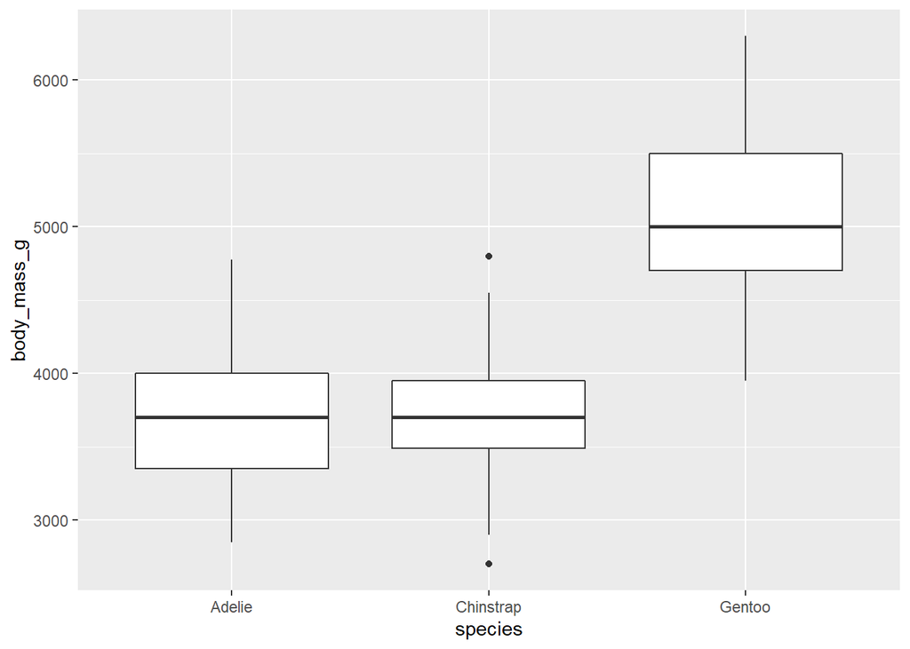

```r
# Does the post-hoc test make sense? View boxplots again.
penguins %>%
  ggplot(mapping = aes(x = species, y = body_mass_g)) +
  geom_boxplot()
```

```r
# Save the output of the ANOVA to a text file
sink(file = "Output/penguin-mass-anova.txt")
summary(object = penguin.mass.aov)
```

```
##              Df    Sum Sq  Mean Sq F value Pr(>F)
## species       2 146864214 73432107   343.6 <2e-16 ***
## Residuals   339  72443483   213698
## ---
## Signif. codes:  0 '***' 0.001 '**' 0.01 '*' 0.05 '.' 0.1 ' ' 1
## 2 observations deleted due to missingness
```

```r
TukeyHSD(x = penguin.mass.aov)
```

```
##   Tukey multiple comparisons of means
##     95% family-wise confidence level
##
## Fit: aov(formula = body_mass_g ~ species, data = penguins)
##
## $species
##                        diff       lwr       upr     p adj
## Chinstrap-Adelie   32.42598 -126.5002  191.3522 0.8806666
## Gentoo-Adelie    1375.35401 1243.1786 1507.5294 0.0000000
## Gentoo-Chinstrap 1342.92802 1178.4810 1507.3750 0.0000000
```

```r
sink()

### Challenge 2
# is there a difference in bill depth among the three penguin species?
# If so, which are species are different from each other?
# test normality, look at the standard deviation, if cool, do a t-test

# hist(penguins$bill_depth_mm)
#
# penguin.depth.aov <- aov(formula = bill_depth_mm ~ species, data = penguins)
#
# penguin.depth.aov
#
# summary(object = penguin.depth.aov)
#
# TukeyHSD(x = penguin.depth.aov)
#
# # Does the post-hoc test make sense? View boxplots again.
# penguins %>%
#   ggplot(mapping = aes(x = species, y = bill_depth_mm)) +
#   geom_boxplot()
```

## Simple Linear Regression

- Regressions, of which there are many, describe the relationship between variables by fitting a line to the observed data
- Linear regression models use a straight line, compared nonlinear model would be a curved line
- Estimate how a dependent variable (Y) changes as an independent variable (X) changes
- Simple linear regression used to estimate the relationship between two quantitative variables:
  - Asks, how strong is the relationship
  - Or, what is the estimated value of the dependent variable given a value for independent variable
  - Y = B0 + B1*X + e
- Assumptions
  - The observations are obtained independently and randomly from the population
  - Normal distribution
  - Homogeneity of variance (roughly equal variance/standard deviations of samples are approximately equal)
  - Important addition: relationship between the two variables is linear

```r
# Next, simple linear regression, let's look at some new data

# Use a data set called gapminder, which is a Swedish non-profit that aggregates
# World data to allow people to ask global social questions

# install.packages("gapminder")
library(gapminder)
# Look at data
glimpse(gapminder)
```

```
## Rows: 1,704
## Columns: 6
## $ country   <fct> Afghanistan, Afghanistan, Afghanistan, Afghanistan, Afgha...
## $ continent <fct> Asia, Asia, Asia, Asia, Asia, Asia, Asia, Asia, Asia, Asi...
## $ year      <int> 1952, 1957, 1962, 1967, 1972, 1977, 1982, 1987, 1992, 199...
## $ lifeExp   <dbl> 28.801, 30.332, 31.997, 34.020, 36.088, 38.438, 39.854, 4...
## $ pop       <int> 8425333, 9240934, 10267083, 11537966, 13079460, 14880372,...
## $ gdpPercap <dbl> 779.4453, 820.8530, 853.1007, 836.1971, 739.9811, 786.113...
```

```r
summary(gapminder)
```

```
##         country        continent        year         lifeExp
##  Afghanistan:  12   Africa  :624   Min.   :1952   Min.   :23.60
##  Albania    :  12   Americas:300   1st Qu.:1966   1st Qu.:48.20
##  Algeria    :  12   Asia    :396   Median :1980   Median :60.71
##  Angola     :  12   Europe  :360   Mean   :1980   Mean   :59.47
##  Argentina  :  12   Oceania : 24   3rd Qu.:1993   3rd Qu.:70.85
##  Australia  :  12                  Max.   :2007   Max.   :82.60
##  (Other)    :1632
##       pop              gdpPercap
##  Min.   :6.001e+04   Min.   :   241.2
##  1st Qu.:2.794e+06   1st Qu.:  1202.1
##  Median :7.024e+06   Median :  3531.8
##  Mean   :2.960e+07   Mean   :  7215.3
##  3rd Qu.:1.959e+07   3rd Qu.:  9325.5
##  Max.   :1.319e+09   Max.   :113523.1
##
```

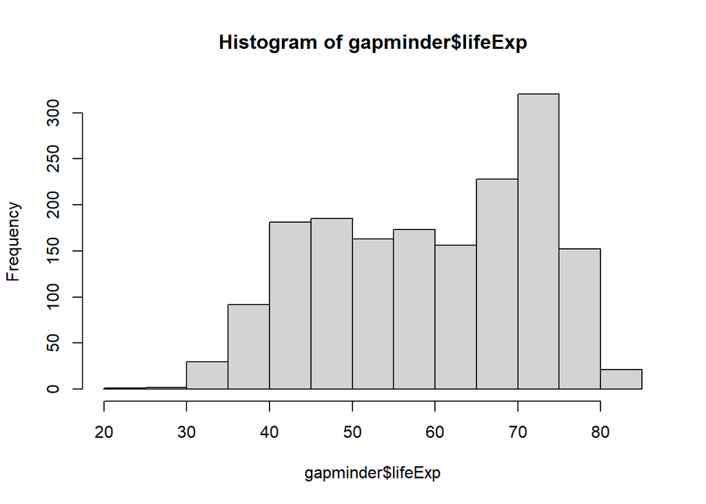

```r
# Linear regression is about understanding relationships
# What's the relationship between wealth and life expectancy?
# What columns would I need to answer this question (lifeExp, gdpPercap)
# Also, if I know the gdp, can I accurately predict the mean life expectancy?

# close to normal, not horrible
hist(gapminder$lifeExp)
```

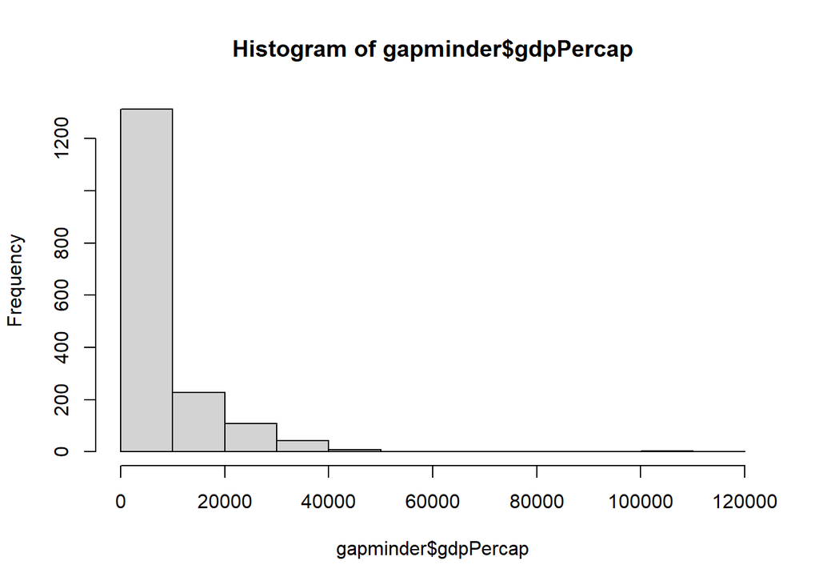

```r
# wooooow that's not normal
hist(gapminder$gdpPercap)
```

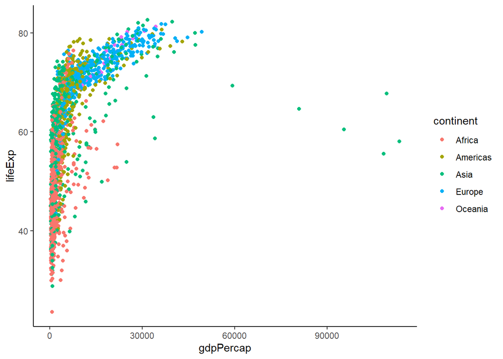

```r
# fail normality assumption, know we're gonna have to address this

# is there a linear relationship, nooo
gapminder_fig <- gapminder %>%
  ggplot(mapping = aes(x = gdpPercap, y = lifeExp, color = continent)) +
  geom_point() +
  #scale_color_manual(values = c("blue", "darkorange", "darkgreen", "darkred", "purple")) +
  theme_classic()

gapminder_fig
```

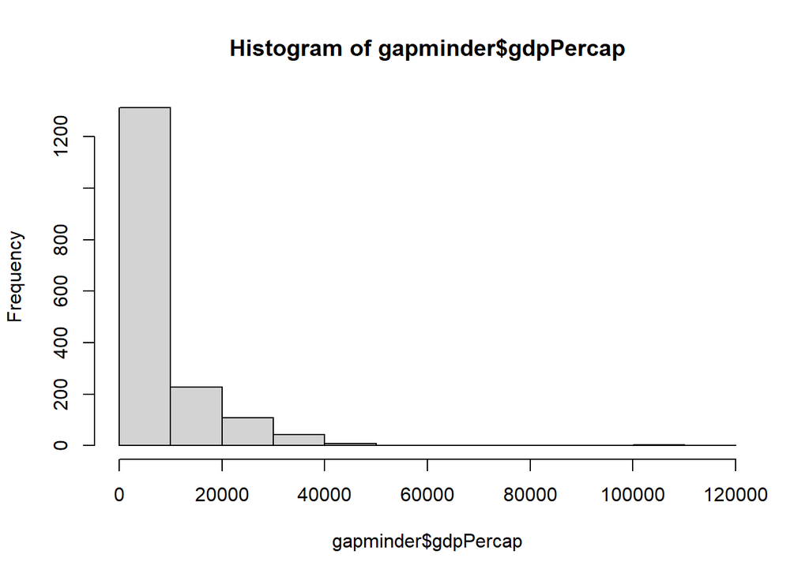

```r
# we can transform data to conform to the SLR assumptions
hist(gapminder$gdpPercap)
```

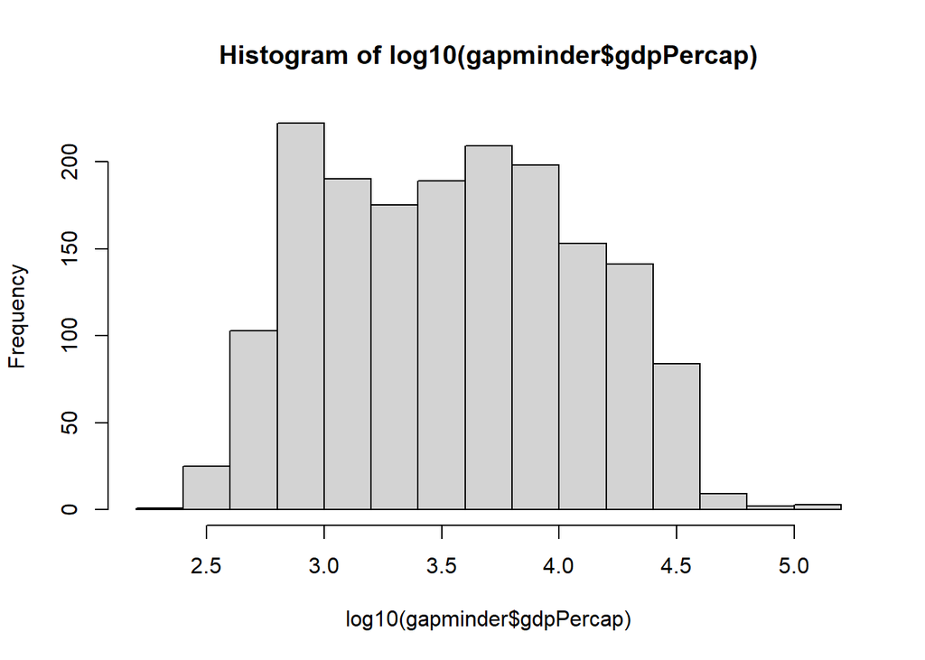

```r
# log is one of the most common ways, but also sqrt, exp
hist(log10(gapminder$gdpPercap))
```

```r
# create a new column of log transformed data, do we remember the tidyverse function?
gapminder_log <- gapminder %>%
  mutate(gdp_log = log10(gdpPercap))

head(gapminder_log)
```

| country | continent | year | lifeExp | pop | gdpPercap | gdp_log |
| --- | --- | --- | --- | --- | --- | --- |
| Afghanistan | Asia | 1952 | 28.801 | 8425333 | 779.4453 | 2.891786 |
| Afghanistan | Asia | 1957 | 30.332 | 9240934 | 820.8530 | 2.914265 |
| Afghanistan | Asia | 1962 | 31.997 | 10267083 | 853.1007 | 2.931000 |
| Afghanistan | Asia | 1967 | 34.020 | 11537966 | 836.1971 | 2.922309 |
| Afghanistan | Asia | 1972 | 36.088 | 13079460 | 739.9811 | 2.869221 |
| Afghanistan | Asia | 1977 | 38.438 | 14880372 | 786.1134 | 2.895485 |

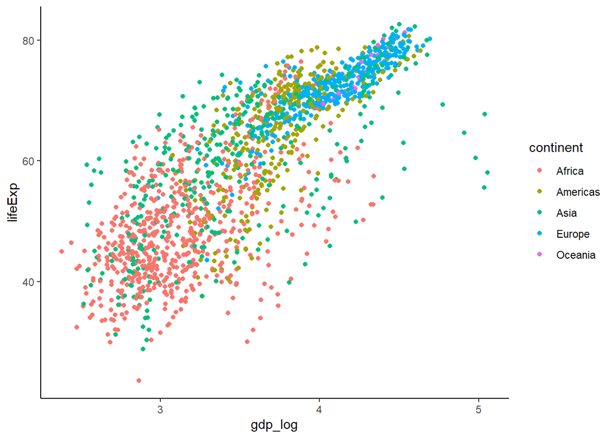

```r
# look at the general relationship between life exp and log gdp
gapminder_log_fig <- gapminder_log %>%
  ggplot(mapping = aes(y = lifeExp, x = gdp_log, color = continent)) +
  geom_point() +
  #scale_color_manual(values = c("blue", "darkorange", "darkgreen", "darkred", "purple")) +
  theme_classic()

gapminder_log_fig
```

```r
# Meeting assumption, now we can do the test/model
# test the relationship
gdp_v_life_model <- lm(formula = lifeExp ~ gdp_log, data = gapminder_log)

gdp_v_life_model
```

```
##
## Call:
## lm(formula = lifeExp ~ gdp_log, data = gapminder_log)
##
## Coefficients:
## (Intercept)      gdp_log
##      -9.101       19.353
```

```r
summary(gdp_v_life_model)
```

```
##
## Call:
## lm(formula = lifeExp ~ gdp_log, data = gapminder_log)
##
## Residuals:
##     Min      1Q  Median      3Q     Max
## -32.778  -4.204   1.212   4.658  19.285
##
## Coefficients:
##             Estimate Std. Error t value Pr(>|t|)
## (Intercept)  -9.1009     1.2277  -7.413 1.93e-13 ***
## gdp_log      19.3534     0.3425  56.500  < 2e-16 ***
## ---
## Signif. codes:  0 '***' 0.001 '**' 0.01 '*' 0.05 '.' 0.1 ' ' 1
##
## Residual standard error: 7.62 on 1702 degrees of freedom
## Multiple R-squared:  0.6522, Adjusted R-squared:  0.652
## F-statistic:  3192 on 1 and 1702 DF,  p-value: < 2.2e-16
```

### LM Output

- Call
  - Function used for regression model
- Residuals
  - Mean = zero by definition
  - Median should be close to zero
  - minimum and maximum should be roughly equal in absolute value
- Coefficients
  - Regression beta coefficients for equation
  - St. Err (accuracy of the beta coefficients)
  - Predictor significance based off t-statistic
- Residual standard error
  - Measure of patterns in the data that can’t be explained by the model
  - When comparing two models, the model with the small RSE is a good indication that this model fits the best the data
  - Closer to zero, better
- R-2
  - Proportion (b/w 0 – 1) of information (variation) in the data that can be explained by the model
  - higher the better
- Adjusted-R2
  - Adjusted R-squared adjusts for the degrees of freedom (penalizes based on number of predictors in model)
- F-statistic
  - Overall significance of the model
    - Is at least one predictor’s coefficient significantly different than zero?
  - Higher the better

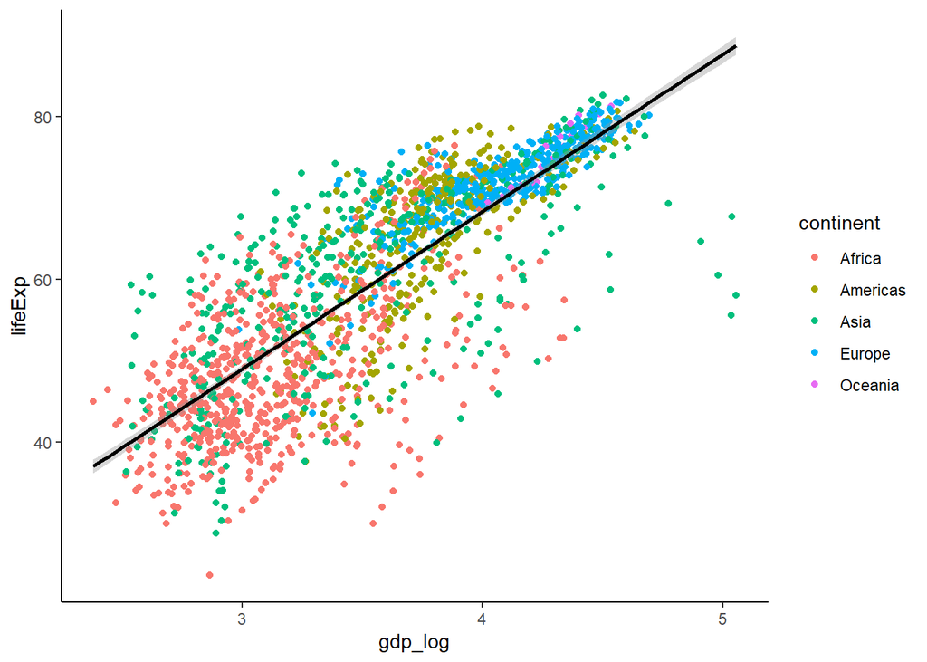

```r
# look at line
gapminder_lm_fig <- gapminder_log %>%
  ggplot(mapping = aes(y = lifeExp, x = gdp_log, color = continent)) +
  geom_point() +
  geom_smooth(method = "lm", color = "black") +
  #scale_color_manual(values = c("blue", "darkorange", "darkgreen", "darkred", "purple")) +
  theme_classic()

gapminder_lm_fig
```

```r
# Save the output of the LM to a text file
sink(file = "Output/log-gdp-life-lm.txt")
summary(object = gdp_v_life_model)
```

```
##
## Call:
## lm(formula = lifeExp ~ gdp_log, data = gapminder_log)
##
## Residuals:
##     Min      1Q  Median      3Q     Max
## -32.778  -4.204   1.212   4.658  19.285
##
## Coefficients:
##             Estimate Std. Error t value Pr(>|t|)
## (Intercept)  -9.1009     1.2277  -7.413 1.93e-13 ***
## gdp_log      19.3534     0.3425  56.500  < 2e-16 ***
## ---
## Signif. codes:  0 '***' 0.001 '**' 0.01 '*' 0.05 '.' 0.1 ' ' 1
##
## Residual standard error: 7.62 on 1702 degrees of freedom
## Multiple R-squared:  0.6522, Adjusted R-squared:  0.652
## F-statistic:  3192 on 1 and 1702 DF,  p-value: < 2.2e-16
```

```r
sink()

# lifeExp = -9.1 + 19.35*log10(gdpPercap)


# Challenge 3
# Is there a relationship between population size and lifeExp for 2002
# Does having a larger population mean you may live longer?
# No, not linear, no stastical relationship

# hist(gapminder_log$pop)
# hist(log10(gapminder_log$pop))
#
# gap_2002 <- gapminder_log %>% filter(year == 2002) %>% mutate(pop_log = log10(pop))
#
# hist(gap_2002$pop_log)
#
# gdp_v_pop_model <- lm(formula = pop_log ~ lifeExp, data = gap_2002)
#
# gdp_v_pop_model
#
# summary(gdp_v_pop_model)
#
# gapminder_pop2002_fig <- gap_2002 %>%
#   ggplot(mapping = aes(y = pop_log, x = lifeExp)) +
#   geom_point() +
#   theme_classic()
#
# gapminder_pop2002_fig
#
```

# R + Statistical Resources

- [Intro to Statistical Learning w/ Applications in R](https://www.statlearning.com/)
- [R for Data Science](https://r4ds.had.co.nz/)
- [Choosing the best statistical test](https://stats.idre.ucla.edu/other/mult-pkg/whatstat/)
- [Datacamp’s statistics page](https://www.statmethods.net/stats/index.html)
- [Dr. Derek Sonderegger Intro to Stat Methods](https://bookdown.org/dereksonderegger/570/)
- [Big Book of R](https://www.bigbookofr.com/index.html)
- [UA UITS Statistical Consulting](https://uarizona.service-now.com/sp?id=sc_cat_item&sys_id=c363b9ae1bdd70107947edf1604bcbb0)
  - Email: stat-consult@list.arizona.edu